# STA4001 Project Report

#### 1.4.2. K = 200

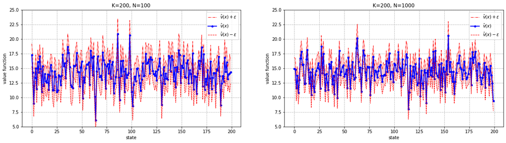

```python
fig_200 = plt.figure(figsize = (20, 5)) # K = 200

# plot N = 100
sub_1= plt.subplot(1, 2, 1)
sub_1.set_ylim(5, 25)
# the right endpoint of confidence inteval
plt.plot(train_200_2[:, -1], color='red', ls="-.", label='$\hat v(x)+\epsilon$', lw=1)
# the point estimate of value function
plt.plot(train_200_2[:, -3], color='blue', marker = 'o', label='$\hat v(x)$', lw=2, ms=4)
# the left endpoint of confidence interval
plt.plot(train_200_2[:, -2], color='red', ls="--", label='$\hat v(x)-\epsilon$', lw=1)
# color the confidence interval red
plt.fill_between(x=np.arange(0, 200, 1), y1=train_200_2[:, -2], y2=train_200_2[:, -1], facecolor="red", alpha=0.2)
plt.title('K=200, N=100')
plt.xlabel('state')
plt.ylabel('value function')
plt.legend(loc=1)
plt.grid(ls="--")

# plot N = 1000
sub_2=plt.subplot(1, 2, 2)
sub_2.set_ylim(5, 25)
# the right endpoint of confidence inteval
plt.plot(train_200_3[:, -1], color='red',ls="-.",label='$\hat v(x)+\epsilon$', lw=1)
# the point estimate of value function
plt.plot(train_200_3[:, -3], color='blue', marker = 'o', label='$\hat v(x)$', lw=2, ms=4)
# the left endpoint of confidence interval
plt.plot(train_200_3[:, -2], color='red', ls="--",label='$\hat v(x)-\epsilon$', lw=1)
# color the confidence interval red
plt.fill_between(x=np.arange(0, 200, 1), y1=train_200_3[:, -2], y2=train_200_3[:, -1], facecolor="red", alpha=0.2)
plt.title('K=200, N=1000')
plt.xlabel('state')
plt.ylabel('value function')
plt.legend(loc=1)
plt.grid(ls="--")
```

#### 1.4.2. K = 2000

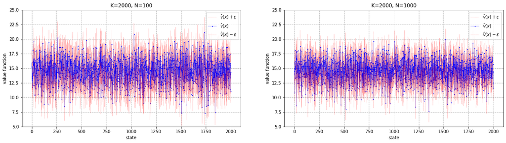

```python
fig_2000 = plt.figure(figsize = (20, 5)) # K = 2000

# plot N = 100
sub_1= plt.subplot(1, 2, 1)
sub_1.set_ylim(5, 25)
# the right endpoint of confidence inteval
plt.plot(train_2000_2[:, -1], color='red', ls="-.", label='$\hat v(x)+\epsilon$', lw=0.15)
# the point estimate of value function
plt.plot(train_2000_2[:, -3], color='blue', marker = 'o', label='$\hat v(x)$', lw=0.3, ms=1)
# the left endpoint of confidence interval
plt.plot(train_2000_2[:, -2], color='red', ls="--", label='$\hat v(x)-\epsilon$', lw=0.15)
# color the confidence interval red
plt.fill_between(x=np.arange(0, 2000, 1),y1=train_2000_2[:, -2], y2=train_2000_2[:, -1], facecolor="red", alpha=0.2)
plt.title('K=2000, N=100')
plt.xlabel('state')
plt.ylabel('value function')
plt.legend(loc=1)
plt.grid(ls="--")

# plot N = 1000
sub_2=plt.subplot(1, 2, 2)
sub_2.set_ylim(5, 25)
# the right endpoint of confidence inteval
plt.plot(train_2000_3[:, -1], color = 'red', ls="-.", label='$\hat v(x)+\epsilon$', lw=0.15)
# the point estimate of value function
plt.plot(train_2000_3[:, -3], color = 'blue', marker = 'o', label='$\hat v(x)$', lw=0.3, ms=1)
# the left endpoint of confidence interval
plt.plot(train_2000_3[:, -2], color = 'red', ls="--", label='$\hat v(x)-\epsilon$', lw=0.15)
# color the confidence interval red
plt.fill_between(x=np.arange(0, 2000, 1), y1=train_2000_3[:, -2], y2=train_2000_3[:, -1], facecolor="red", alpha=0.2)
plt.title('K=2000, N=1000')
plt.xlabel('state')
plt.ylabel('value function')
plt.legend(loc=1)
plt.grid(ls="--")
```

### 1.5. Limitation

Monte Carlo Stimulation is time-cosuming and computationally-demanding. As the state space is large, it is also space consuming to store all the reuslts.  
To see this:

To precisely compute $|S|$, one possible solution is to draw a tree diagram with the help of recursion. However, simple recursion won't work when the height of the tree is very large, which will reuslt in a very deep recursion path and lead to the breakdown of the program. The following code gives an implementation using stack to exhaust all the possible states and returns the cardinality of the state space:

```python
def generateStateSpace(Q, L):
    S = set() # the state space
    X = [0 for i in range(L)] # initial state
    TX = tuple(X) # convert X into hashable type to check uniqueness
    Stack = [TX] # Stack record the parent node in the tree
    S.add(TX) # add the initial state into state space
    D = [0]
    while (len(D) > 0): # while the recursion does not end
        d = D[-1] # enumerate d from X[0] to Q
        # update state given demand d
        X[-1] = Q-max(Stack[-1][0], d)
        for i in range(1, L):
            X[i-1] = max(Stack[-1][i]-max(Stack[-1][0], d), 0)
        TX = tuple(X)
        if TX not in S: # if the new state not in state space
            S.add(TX) # add the new state in
            # increse the recursion depth
            Stack.append(TX)
            D.append(X[0])
        elif (D[-1] < Q): # from one child note to another
            D[-1] += 1
        else:
            # cut the leaves and go back to the parent node
            Stack.pop()
            D.pop()
            if (len(D) == 0): # when the recursion terminates, break
                break
            D[-1] += 1
    return(len(S))
```

To give a illustration, when $Q=20$ and $L=3$:

```python
generateStateSpace(20, 3)
```

```
1771
```

You won't want to run `generateStateSpace(90,6)` because it takes forever to get the result.

## 2. Neuron Network

```python
class neuralNetwork():
    def __init__(self, input_dimension):
        # define the keras model
        self.model = Sequential()
        self.model.add(Dense(5, input_dim=input_dimension,
                             activation='relu'))
        self.model.add(Dense(5, activation='relu'))
        self.model.add(Dense(1, activation='linear'))
        # compile the keras model
        self.model.compile(loss='mean_squared_error', optimizer='adam')

# scale the data
class Scaler:
    # save mean and variance of x, y sets
    def __init__(self, x, y):
        self.x_mean = np.mean(x, axis=0)
        self.y_mean = np.mean(y, axis=0)
        self.x_std = np.std(x, axis=0)
        self.y_std = np.std(y, axis=0)

    def get_x(self):
        # return saved mean and variance of x
        return self.x_std, self.x_mean

    def get_y(self):
        # return saved mean and variance of y
        return self.y_std, self.y_mean
```

### 2.1. K=20

#### 2.1.1. Fit the Model

```python
x_train = train_20_3[:, :L]
y_train = train_20_3[:, L]
x_test = test_50[:, :L]
y_test = test_50[:, L]

# normalize the train and test data
normalizer = Scaler(x_train, y_train)
std_x, mean_x = normalizer.get_x()
x_train_norm = (x_train-mean_x)/std_x
x_test_norm = (x_test-mean_x)/std_x
std_y, mean_y = normalizer.get_y()
y_train_norm = (y_train-mean_y)/std_y

NN1 = neuralNetwork(input_dimension=L)

# fit the data
# set verbose = 0 to silence the processing output
NN1.model.fit(x_train_norm, y_train_norm, epochs=100, batch_size=8, verbose=0)

# generate predicted value function
y_from_nn1_norm = NN1.model.predict(x_test_norm)
y_from_nn1 = y_from_nn1_norm*std_y+mean_y
```

#### 2.1.2. Mean Squared Error

```python
mse = mean_squared_error(y_test, y_from_nn1)
print('Mean squared error: ', mse)
```

```
Mean squared error:  1.6899557083422971
```

#### 2.1.3. Test the Model

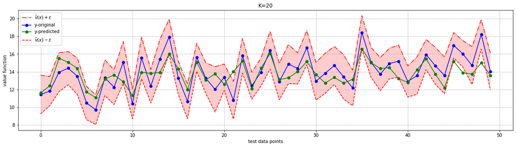

```python
fig_20N = plt.figure(figsize = (20,5)) # K = 20

plt.plot(test_50[:, -1], color = 'red', ls="-.", label='$\hat v(x)+\epsilon$')
plt.plot(test_50[:, -3], color = 'blue',marker = 'o', label='y-original')
plt.plot(y_from_nn1, color = 'green',marker = 'o', label='y-predicted')
plt.plot(test_50[:, -2], color = 'red',ls="--",label='$\hat v(x)-\epsilon$')
plt.fill_between(x=np.arange(0, 50, 1), y1=test_50[:, -2], y2=test_50[:, -1], facecolor="red", alpha=0.2)
plt.title('K=20')
plt.xlabel('test data points')
plt.ylabel('value function')
plt.legend(loc=2)
plt.grid(ls="--")
```

#### 2.1.4. Predict

```python
print('Initial State:\t', (np.array([10, 20, 30, 40, 50, 80])))
print('Neural Network:\t', (NN1.model.predict(((np.array([[10, 20, 30, 40, 50, 80]])-mean_x)/std_x))*std_y+mean_y)[0][0])
MC = MonteCarlo(10**3, np.array([10, 20, 30, 40, 50, 80]))
print('MonteCarlo:\t', MC[0])
print('MonteCarlo CI:\t[', MC[1], ', ', MC[2],']', sep='')
```

```
Initial State:	 [10 20 30 40 50 80]
Neural Network:	 16.378511
MonteCarlo:	 17.49736435397056
MonteCarlo CI:	[17.156497565305322, 17.8382311426358]
```

### 2.2. K=200

#### 2.2.1. Fit the Model

```python
x_train = train_200_3[:, :L]
y_train = train_200_3[:, L]
x_test = test_50[:, :L]
y_test = test_50[:, L]

# normalize the train and test data
normalizer = Scaler(x_train, y_train)
std_x, mean_x = normalizer.get_x()
x_train_norm = (x_train - mean_x) / std_x
x_test_norm = (x_test - mean_x) / std_x
std_y, mean_y = normalizer.get_y()
y_train_norm = (y_train - mean_y) / std_y

NN2 = neuralNetwork(input_dimension=L)

# fit the data
# set verbose = 0 to silence the processing output
NN2.model.fit(x_train_norm, y_train_norm, epochs=100, batch_size=8, verbose=0)

# generate predicted value function
y_from_nn2_norm = NN2.model.predict(x_test_norm)
y_from_nn2 = y_from_nn2_norm * std_y + mean_y
```

#### 2.2.2. Mean Squared Error

```python
mse = mean_squared_error(y_test, y_from_nn2)
print('Mean squared error: ', mse)
```

```
Mean squared error:  1.1659013233236868
```

#### 2.2.3. Test the Model

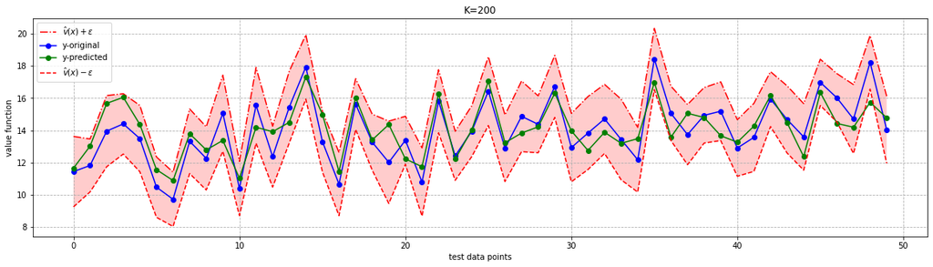

```python
fig_200N = plt.figure(figsize = (20,5)) # K = 200

plt.plot(test_50[:,-1], color = 'red', ls="-.",label='$\hat v(x)+\epsilon$')
plt.plot(test_50[:,-3], color = 'blue',marker = 'o', label='y-original')
plt.plot(y_from_nn2, color = 'green',marker = 'o', label='y-predicted')
plt.plot(test_50[:,-2], color = 'red',ls="--",label='$\hat v(x)-\epsilon$')
plt.fill_between(x=np.arange(0,50,1),y1=test_50[:, -2], y2=test_50[:, -1], facecolor="red", alpha=0.2)
plt.title('K=200')
plt.xlabel('test data points')
plt.ylabel('value function')
plt.legend(loc=2)
plt.grid(ls="--")
```

#### 2.2.4. Predict

```python
print('Initial State:\t', (np.array([10, 20, 30, 40, 50, 80])))
print('Neural Network:\t', (NN2.model.predict(((np.array([[10, 20, 30, 40, 50, 80]])-mean_x)/std_x))* std_y+mean_y)[0][0])
MC = MonteCarlo(10**3, np.array([10, 20, 30, 40, 50, 80]))
print('MonteCarlo:\t', MC[0])
print('MonteCarlo CI:\t[', MC[1], ', ', MC[2], ']',sep='')
```

```
Initial State:	 [10 20 30 40 50 80]
Neural Network:	 17.347094
MonteCarlo:	 17.188584620132517
MonteCarlo CI:	[16.85684963332085, 17.520319606944184]
```

### 2.3. K=2000

#### 2.3.1. Fit the Model

```python
x_train = train_2000_3[:, :L]
y_train = train_2000_3[:, L]
x_test = test_50[:, :L]
y_test = test_50[:, L]

# normalize the train and test data
normalizer = Scaler(x_train, y_train)
std_x, mean_x = normalizer.get_x()
x_train_norm = (x_train - mean_x) / std_x
x_test_norm = (x_test - mean_x) / std_x
std_y, mean_y = normalizer.get_y()
y_train_norm = (y_train - mean_y) / std_y

NN3 = neuralNetwork(input_dimension=L)

# fit the data
# set verbose = 0 to silence the processing output
NN3.model.fit(x_train_norm, y_train_norm, epochs=100, batch_size=8, verbose=0)

# generate predicted value function
y_from_nn3_norm = NN3.model.predict(x_test_norm)
y_from_nn3 = y_from_nn3_norm * std_y + mean_y
```

#### 2.3.2. Mean Squared Error

```python
mse = mean_squared_error(y_test, y_from_nn3)
print('Mean squared error: ', mse)
```

```
Mean squared error:  1.1904237072409136
```

#### 2.3.3. Test the Model

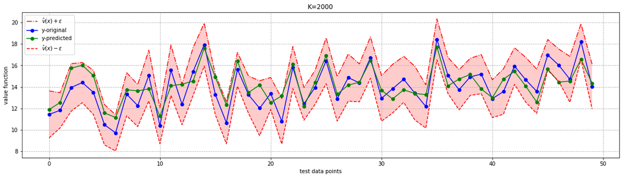

```python
fig_2000N = plt.figure(figsize = (20, 5)) # K = 2000

plt.plot(test_50[:, -1], color = 'red', ls="-.", label='$\hat v(x)+\epsilon$')
plt.plot(test_50[:, -3], color = 'blue', marker = 'o', label='y-original')
plt.plot(y_from_nn3, color = 'green', marker = 'o', label='y-predicted')
plt.plot(test_50[:, -2], color = 'red', ls="--", label='$\hat v(x)-\epsilon$')
plt.fill_between(x=np.arange(0, 50, 1), y1=test_50[:, -2], y2=test_50[:, -1], facecolor="red", alpha=0.2)
plt.title('K=2000')
plt.xlabel('test data points')
plt.ylabel('value function')
plt.legend(loc=2)
plt.grid(ls="--")
```

#### 2.3.4. Predict

```python
print('Initial State:\t', (np.array([10, 20, 30, 40, 50, 80])))
print('Neural Network:\t', (NN3.model.predict(((np.array([[10, 20, 30, 40, 50, 80]])-mean_x)/std_x))* std_y + mean_y)[0][0])
MC = MonteCarlo(10**3, np.array([10, 20, 30, 40, 50, 80]))
print('MonteCarlo:\t', MC[0])
print('MonteCarlo CI:\t[', MC[1], ', ', MC[2], ']', sep='')
```

```
Initial State:	 [10 20 30 40 50 80]
Neural Network:	 17.063206
MonteCarlo:	 17.267245684548296
MonteCarlo CI:	[16.927039819185133, 17.60745154991146]
```

The End of Report